# **Exportações brasileiras**

| Categoria | 01/2016 | 12/2015 | 01/2015 |
| --- | --- | --- | --- |
| Produtos alimentícios e animais vivos | 3.3202 | 4.5630 | 4.0040 |
| Bebidas e tabaco | 0.0798 | 0.1266 | 0.1489 |
| Materiais em bruto, não comestíveis, exceto combustível | 2.1198 | 3.0241 | 2.5771 |
| Combustiveis mineirais, lubrificantes e materiais relacionados | 0.8821 | 0.9808 | 1.3543 |
| Óleos animais e vegetais, gorduras e ceras | 0.0722 | 0.1539 | 0.1125 |
| Produtos químicos e relacionados | 0.7829 | 0.9229 | 0.9147 |
| Artigos manufaturados, classificados principalmente pelo material | 1.4827 | 1.9562 | 1.9782 |
| Máquinas e equipamentos de transporte | 1.6393 | 3.1960 | 1.5909 |
| Obras diversas | 0.2342 | 0.3909 | 0.2578 |
| Mercadoria e transações não especificadas em outras partes da CUCI | 0.4115 | 0.3799 | 0.5431 |
| Exportação total | 10.9524 | 15.5404 | 13.3690 |

[figure not shown]

Entre as categorias, a que apresentou maior variação mensal em relação ao seu peso na exportação total foi “**Mercadoria e transações não especificadas em outras partes da CUCI**”, em que seu peso foi **3.757%** e a variação **8.31%**.

| Categoria | Valor(bilhões de US$) | Variação mensal | Variação em 12 meses | Peso na Exportação total |
| --- | --- | --- | --- | --- |
| Produtos alimentícios e animais vivos | 3.3202 | -27.23% | -17.08% | 30.315% |
| Bebidas e tabaco | 0.0798 | -36.98% | -46.42% | 0.729% |
| Materiais em bruto, não comestíveis, exceto combustível | 2.1198 | -29.90% | -17.75% | 19.355% |
| Combustiveis mineirais, lubrificantes e materiais relacionados | 0.8821 | -10.06% | -34.87% | 8.054% |
| Óleos animais e vegetais, gorduras e ceras | 0.0722 | -53.09% | -35.83% | 0.659% |
| Produtos químicos e relacionados | 0.7829 | -15.18% | -14.42% | 7.148% |
| Artigos manufaturados, classificados principalmente pelo material | 1.4827 | -24.20% | -25.05% | 13.538% |
| Máquinas e equipamentos de transporte | 1.6393 | -48.71% | 3.04% | 14.968% |
| Obras diversas | 0.2342 | -40.09% | -9.17% | 2.138% |
| Mercadoria e transações não especificadas em outras partes da CUCI | 0.4115 | 8.31% | -24.24% | 3.757% |
| Exportação total | 10.9524 | -29.52% | -18.08% | 100.000% |

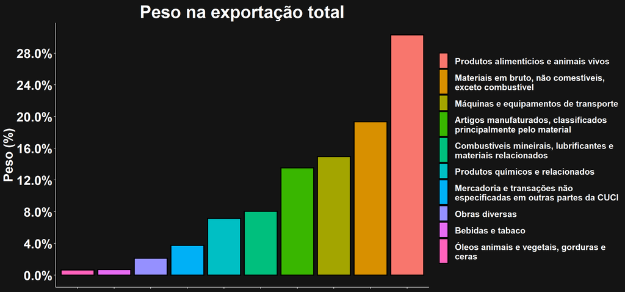

A nível de produtos, os que apresentaram maior resultado foram: **Óleos brutos de petróleo ou de minerais betuminosos, crus** (0.81 bilhões de US$), **Milho não moído, exceto milho doce** (0.74 bi), **Minério de ferro e seus concentrados** (0.66 bi), **Celulose** (0.49 bi), **Farelos de soja e outros alimentos para animais (excluídos cereais não moídos), farinhas de carnes e outros animais** (0.44 bi).

| Produto | 01/2016 | 12/2015 | 01/2015 |
| --- | --- | --- | --- |
| Óleos brutos de petróleo ou de minerais betuminosos, crus | 0.8115 | 0.8762 | 1.1887 |
| Milho não moído, exceto milho doce | 0.7366 | 1.0497 | 0.5984 |
| Minério de ferro e seus concentrados | 0.6561 | 1.2749 | 1.1967 |
| Celulose | 0.4911 | 0.5167 | 0.4230 |
| Farelos de soja e outros alimentos para animais (excluídos cereais não moídos), farinhas de carnes e outros animais | 0.4381 | 0.4088 | 0.4292 |

## **Gráficos por categoria**

[figure not shown]

[figure not shown]

[figure not shown]

[figure not shown]

## **Estatísticas**

Estatísticas 10 anos (Valores em bilhões de US$)

| Categoria | Minímo | 1º Quartil | Mediana | Média | 3º Quartil | Máximo | Valor Observado |
| --- | --- | --- | --- | --- | --- | --- | --- |
| Produtos alimentícios e animais vivos | 1.477 | 2.807 | 3.570 | 3.625 | 4.365 | 6.537 | 3.3202 |
| Bebidas e tabaco | 0.03467 | 0.14730 | 0.20178 | 0.23098 | 0.31369 | 0.52192 | 0.0798 |
| Materiais em bruto, não comestíveis, exceto combustível | 1.279 | 2.416 | 3.823 | 4.123 | 5.421 | 8.230 | 2.1198 |
| Combustiveis mineirais, lubrificantes e materiais relacionados | 0.4215 | 1.0201 | 1.4172 | 1.5076 | 1.8690 | 3.3063 | 0.8821 |
| Óleos animais e vegetais, gorduras e ceras | 0.02996 | 0.11163 | 0.14279 | 0.15720 | 0.19270 | 0.41327 | 0.0722 |
| Produtos químicos e relacionados | 0.5529 | 0.9008 | 1.0004 | 1.0255 | 1.1604 | 1.5093 | 0.7829 |
| Artigos manufaturados, classificados principalmente pelo material | 1.348 | 1.890 | 2.098 | 2.090 | 2.295 | 3.051 | 1.4827 |
| Máquinas e equipamentos de transporte | 1.588 | 2.428 | 2.859 | 2.802 | 3.159 | 3.904 | 1.6393 |
| Obras diversas | 0.2342 | 0.3719 | 0.4020 | 0.4039 | 0.4363 | 0.5377 | 0.2342 |
| Mercadoria e transações não especificadas em outras partes da CUCI | 0.2162 | 0.3627 | 0.4833 | 0.4828 | 0.6082 | 0.8255 | 0.4115 |
| Exportação total | 8.681 | 13.438 | 15.761 | 16.291 | 19.389 | 25.866 | 10.9524 |

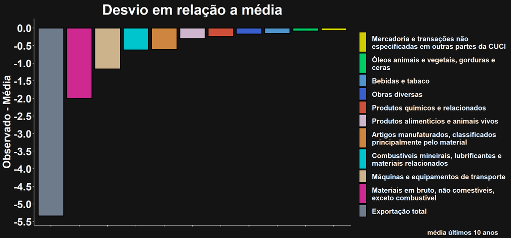

João Victor Gomes

jvg.santana@gmail.com

linkedin.com/in/jvictorgomes